# Lab_14

Fantastic Four

# Guiding Question

## What factors lead to on time arrivals? What factors cause flight delays?

It is important to isolate the different events which result in delayed flights and prompt flights in order to improve procedures to make them more effective and give a better assurance that flights will remain on schedule. This information could also help schedule future flights as well as preserve all assets which go into operating airports and flights. The factors we examined were: time, airline, weather, flight time, and length of flight. Although it can be difficult to completely isolate each of these factors (as, in the real world factors are compound), we tried to isolate these elements the best we could.

# Conclusion

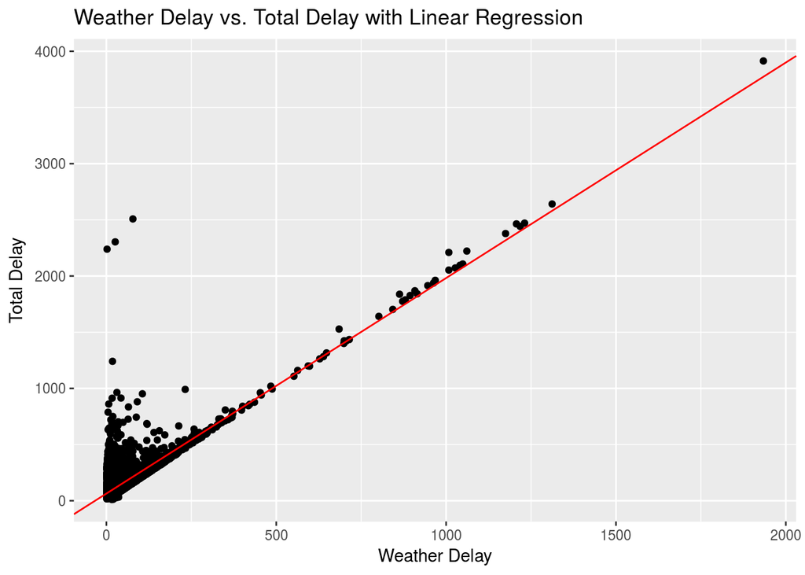

```r
modified_data <- COflights %>%
  filter(ARR_DELAY >=15 | DEP_DELAY>=15, MONTH, DAY_OF_MONTH, !WEATHER_DELAY==0)%>%
  mutate(total_delay= ARR_DELAY+DEP_DELAY)

weTdelay <- lm(total_delay~WEATHER_DELAY,data=modified_data)

ggplot(data= modified_data, mapping=aes(x= WEATHER_DELAY, y= total_delay)) +
  geom_point() +
  geom_abline(slope = weTdelay$coefficients[[2]], intercept = weTdelay$coefficients[[1]], colour = "red")+
  ggtitle("Weather Delay vs. Total Delay with Linear Regression") +
  xlab("Weather Delay") +
  ylab("Total Delay")
```

```r
#modified_data%>%
#  filter(total_delay>=2222) %>%
#  select(MONTH, DAY_OF_MONTH, total_delay)%>%
#  print(MONTH, total_delay)
```

The overall findings of this lab were generally similar to those in Lab 6 but with the use of linear models and iteration we can make conclusions about the information with more certainty. We now are able to better isolate variables to create models to analyze patterns that we can then use to predict future values.

# Recommendations

# Individual Findings

## Lexie Marinelli

Are a majority of flight delays in Colorado caused by weather?

The new tools I used are the linear model function to determine the models slope and intercept and I used the data grid to add predictions and residuals to see how accurate the model is.

Using this model I can determine that weather is a large cause that exibits a linear relationship, there is still a good amount of variance for shorter delayed flights. This relates to the overall question because it addresses areas where DIA can improve. one of areas DIA can improve their efficiency is improving their preparedness for days with bad weather to minimized the number of delayed flights.

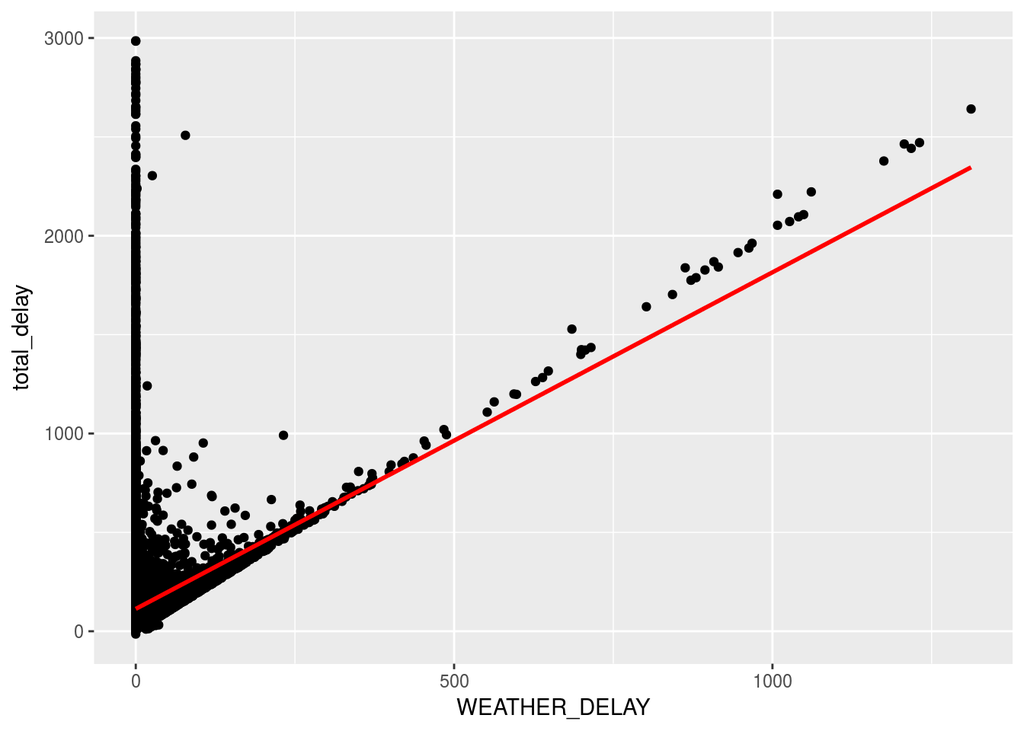

```r
modified_data <-COflights %>%
  filter(ARR_DELAY >=15 | DEP_DELAY>=15, MONTH, DAY_OF_MONTH, WEATHER_DELAY <=1500)%>%
  mutate(total_delay= ARR_DELAY+DEP_DELAY)

delaymod<- lm(total_delay~ WEATHER_DELAY , data= modified_data)

modified_data1 <- modified_data %>%
  data_grid(WEATHER_DELAY) %>%
  add_predictions(delaymod)

ggplot(modified_data, aes(x= WEATHER_DELAY)) +geom_point(aes(y=total_delay)) + geom_line(data= modified_data1, aes(y=pred), size=1, color= "red")
```

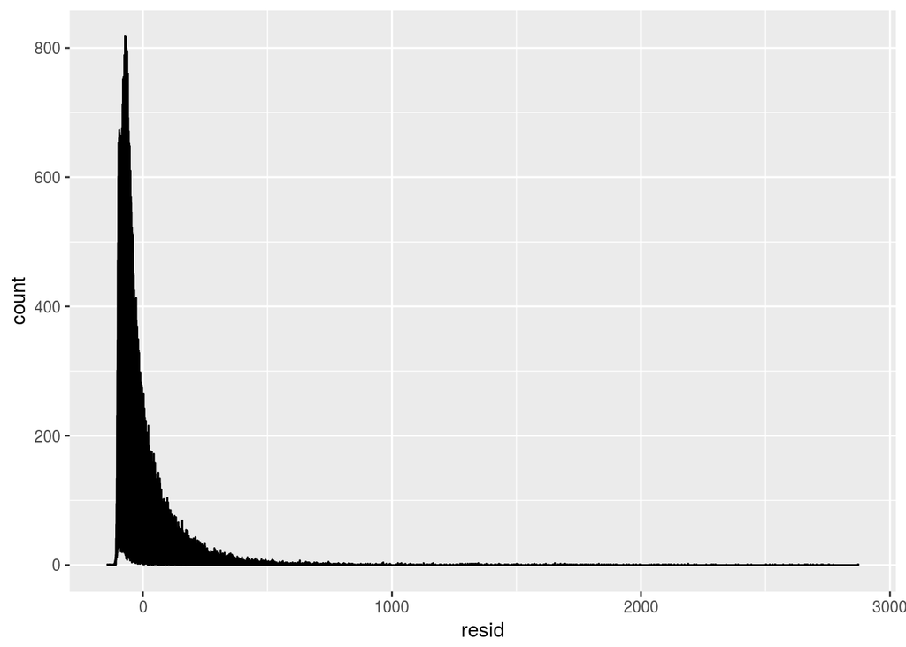

```r
modified_data1<- modified_data %>%
  add_residuals(delaymod)

ggplot(modified_data1, aes(resid)) + geom_freqpoly(binwidth= 0.5)
```

The model I chose to create was relating the total delay an aircraft experiences compared to the number of times it is related to weather. This model is best represented as a linear fit with a slope of 1.702 and a y-intercept of 113.104 The graph shows us that a majority of longer delays are caused by weather with some exceptions for the shorter delay times. Overall this model provides an accurate fit to the weather delay compared to the total delay of flights in Colorado in January.

I have also included a graph of the residuals which shows, for the most part, that the residuals are centered around 0. Some of the larger residuals are causes by other delay factors not including a weather delay but this is just a small amount of the data.

## Lindsay Gettel

How does a late aircraft delay affect the arrival delay of flights into Denver? This is a significant question in order to consider how previous flights affect the timing and schedules of others. If there is a relationship between late aircrafts and arrival delays, then precautions can be taken to avoid late aircrafts, and possibly to adjust precedures inbetween one flight and another to help minumize the domino affect of delayed flights.

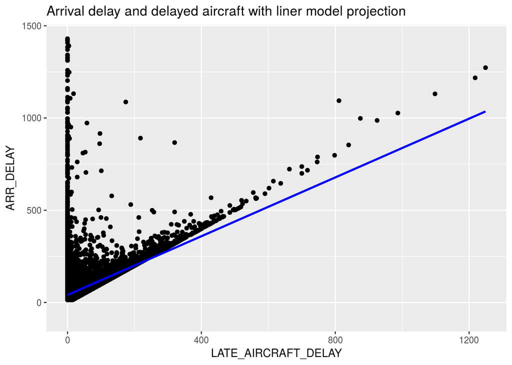

```r
DEN<-COflights%>%
  filter(DEST=="DEN", !is.na(ARR_DELAY))
# COflights%>%
#   filter(DEST=="DEN", !is.na(ARR_DELAY))%>%
#   ggplot()+ geom_point(aes(x=LATE_AIRCRAFT_DELAY, y=ARR_DELAY))

linearModel<-lm(ARR_DELAY~LATE_AIRCRAFT_DELAY, data=DEN)

denPred<-DEN%>%
  data_grid(LATE_AIRCRAFT_DELAY)%>%
  add_predictions(linearModel)

denRes<-DEN%>%
  add_residuals(linearModel)

ggplot(DEN, aes(LATE_AIRCRAFT_DELAY))+ geom_point(aes(y=ARR_DELAY))+ geom_line(aes(y=pred), data=denPred, color="blue", size=1)+ ggtitle("Arrival delay and delayed aircraft with liner model projection")
```

The above graph illustrates the linear model of arrival delay regressed on late aircraft delay. The linear fit seams to model a portion of the data, but is not ideal, it demonsrates a slight positive relationship between late aircraft and arrival delays. The model does not fit due to the vertical spread of plots at which there was no delay due to late aicrafts, but there was still a significant arrival delay This indicates that increased late aircraft delays cause arrival delays, however, it is not the singular factor in late arrivals. Therefore, on time aircrafts, help minimize late arrivals and increase the chance a flight arrives ontime in Denver. To add the linear regression, I utilized the linearization function and applied predictions to to data set based off of the model.

## Zhenlong Li

How does the flying distacne and carrier delay affect the arrival and departure delay time of the flights to/from Denver?

The question is interesting and vital to our overall question since we can foresee the delay by analyzing the dataset of flights in Colorado so that DIA will reduce the delays and rearrage the schedule if they can.

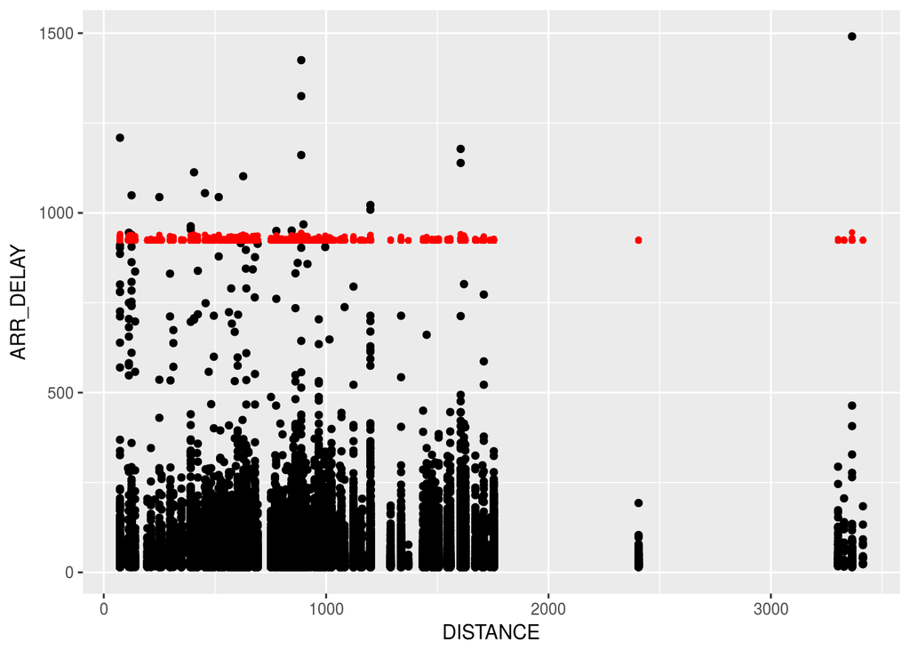

```r
DENflights_arr <- COflights%>%
  filter(ORIGIN=="DEN", !is.na(ARR_DELAY), ARR_DELAY >= 15)%>%
  select(DISTANCE, ARR_DELAY)

DENflights_arr_mod <- lm(DISTANCE ~ ARR_DELAY, data = DENflights_arr, na.action = na.exclude)

grid_arr <- DENflights_arr %>%
  add_predictions(DENflights_arr_mod)

ggplot(DENflights_arr, aes(DISTANCE)) + geom_point(aes(y = ARR_DELAY)) + geom_point(data = grid_arr, aes(y = pred), colour = "red", size = 1)
```

Next, I will use an obvious linear model to analyze the relationship between carrier delay time and departure delay.

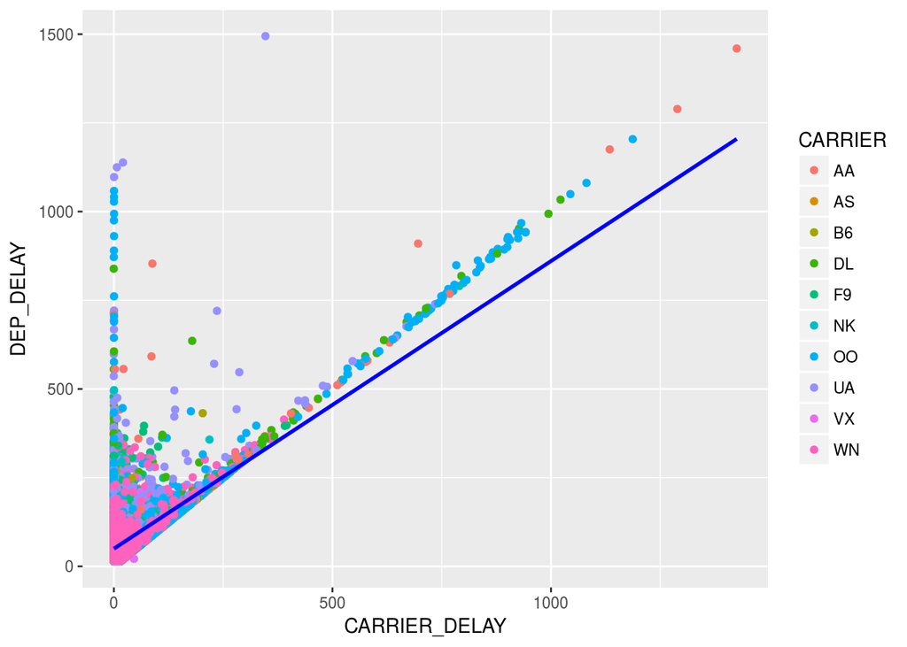

```r
DENflights_dep <- COflights%>%
  filter(ORIGIN=="DEN", !is.na(DEP_DELAY), DEP_DELAY >= 15)%>%
  select(ORIGIN, DEP_DELAY, CARRIER, CARRIER_DELAY)

DENflights_dep_mod <- lm(DEP_DELAY ~ CARRIER_DELAY, data = DENflights_dep, na.action = na.exclude)

grid_dep <- DENflights_dep %>%
  add_predictions(DENflights_dep_mod)

ggplot(DENflights_dep, aes(CARRIER_DELAY,color = CARRIER))+ geom_jitter(aes(y = DEP_DELAY))+ geom_line(aes(y = pred), data = grid_dep, color = "blue", size = 1)
```

From this plot, we can obviously notice that there is a linear relation between carrier delay and departure delay, while the fitted line does not exactly matched the data since the blue line is just a predicted trendline.

## Scott Baker

### Improvements

There are three improvements I made:

- I used factors to reorder the bar graphs that show arrival delay and departure delay counts by airline.
- I applied a linear regression to look at the relationship between arrival delay and deparure delay.
- I conducted a hypothesis test looking at the percentage of Southwest flights (out of the total) that arrive late.

Most of the analysis remains the same as the original lab. However, by changing the three aspects described above, my code is cleaner and the visuals provides more convincing support to the analysis already done.

### Analysis

First, I take a look at the number of flights that arrived late (more than 15 minutes) into Denver based on airline. Here is the graph:

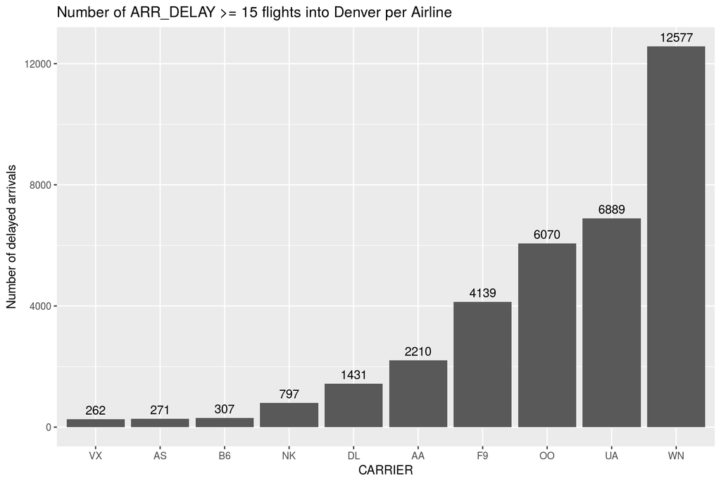

```r
stuff <- filter(COflights,ARR_DELAY >= 15, DEST == "DEN") %>% select(CARRIER) %>%  group_by(CARRIER) %>% summarise(count=n())

stuff$CARRIER <- factor(stuff$CARRIER,levels = stuff$CARRIER[order(stuff$count)])

ggplot(stuff, aes(x = CARRIER, y = count)) +
  geom_bar(stat = "identity") +
  geom_text(aes(label=count),vjust =-0.5) +
  ggtitle("Number of ARR_DELAY >= 15 flights into Denver per Airline") +
  ylab("Number of delayed arrivals")
```

The first major observation is that airlines “WN”, “UA”, and “OO” have the most flights delayed landing. * Southwest (WN): 12577 * United (UA): 6889 * SkyWest (OO): 6070

[figure not shown]

```r
stuff2 <- filter(COflights,DEP_DELAY >= 15, ORIGIN == "DEN") %>% select(CARRIER) %>%  group_by(CARRIER) %>% summarise(count=n())

stuff2$CARRIER <- factor(stuff2$CARRIER,levels = stuff2$CARRIER[order(stuff2$count)])

ggplot(stuff2, aes(x = CARRIER, y = count)) +
  geom_bar(stat = "identity") +
  geom_text(aes(label=count),vjust =-0.5) +
  ggtitle("Number of DEP_DELAY >= 15 flights into Denver per Airline") +
  ylab("Number of delayed arrivals")
```

The second part of my analysis is to show that there is a strong correlation between the departure delay and the tardiness of their arrival:

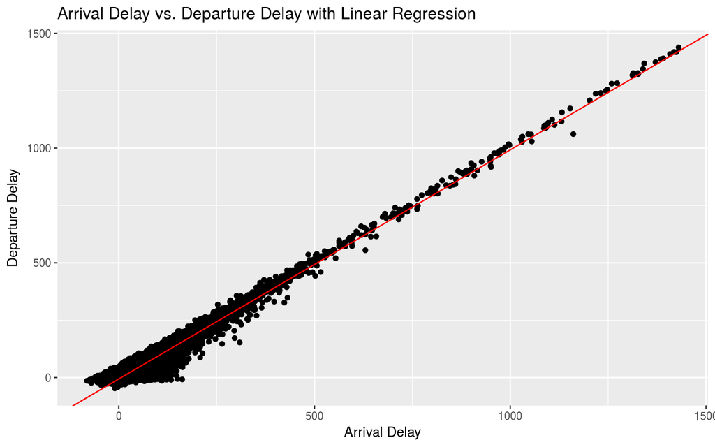

```
## [1] 0.9569532
```

From this we have two results. First, the correlation value between arrival delay (in Denver) and departure delay is .957, which is a strong correlation. Second, the implication of this is that there sometimes might not be anything DIA can do better to ensure more flights are on time–it could all be a product of the departure airport and their inability to get planes off in time.

```r
dfTest <- filter(COflights,ARR_DELAY >= 15, DEST == "DEN") %>% select(CARRIER)
i <- 0
#this is the number of iterations:
len <- 1000
output <- as.data.frame(1:len)
#output
colnames(output) <- c("values")
#ITERATION:
while(i < len){
  temp <- sample_n(dfTest,100,replace=TRUE)
  meanT <- temp %>% group_by(CARRIER) %>% summarise(count=n()) %>% filter(CARRIER == "WN")
  output[i+1,1] <- meanT$count/100
  i <- i + 1
}
#output
```

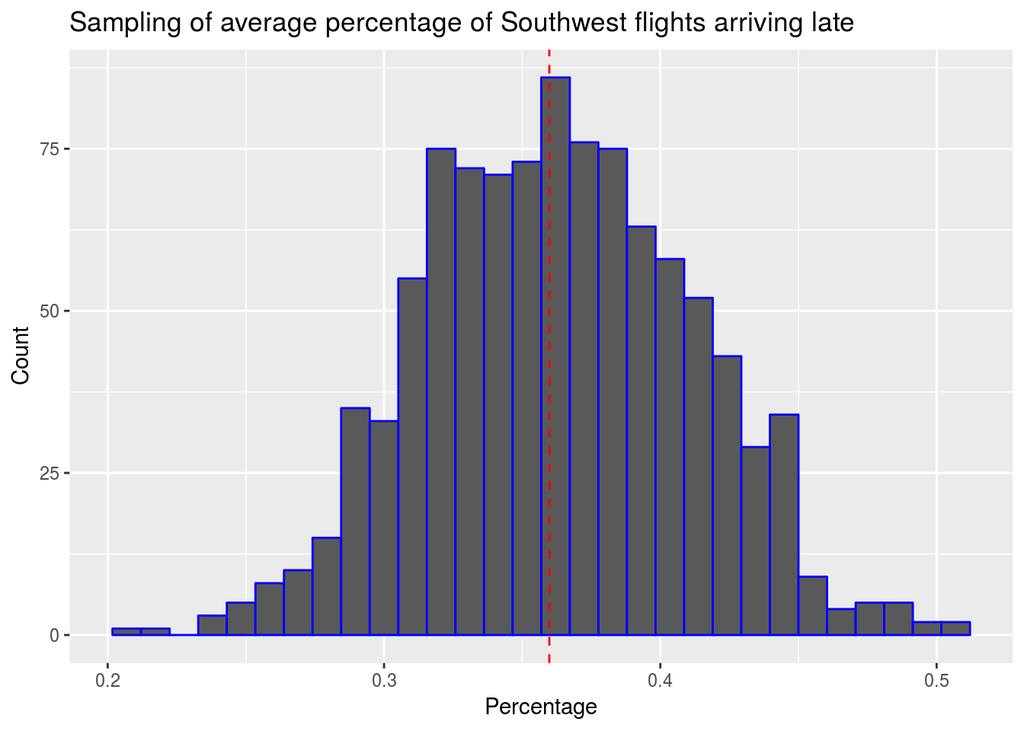

```r
mSt <- 12577 / sum(stuff$count)


ggplot(data=output) + geom_histogram(mapping=aes(values),color="blue", bins=30) +
  geom_vline(aes(xintercept = mSt),color="red",lty=2) +
  #geom_text(aes(x=.35, label="mean", y=100), colour="red", angle=90, text=element_text(size=20)) +
  xlab("Percentage") +
  ylab("Count") +
  ggtitle("Sampling of average percentage of Southwest flights arriving late")
```

```r
#mean of the test stat 1K
MM <- sapply(output,mean)
#standard deviation of the test stat 1K
SS <- sapply(output,sd)

#zscore SW percentage
z60 <- (mSt - MM)/SS
```

# Contributions

- Lindsay: Created a model to add predictions and determine if there is linear relationship between arrival delays to Denver and aircraft delays.
- Lexie: Created individual plots and analyzed what information we have learned. Also created conclusion summarizing this lab.
- Li: Initialized the write-up on git and impovred my previous analysis which is how distance and carrier delay affected a flight by using packages: modelr, tidyverse and ggplot2.
- Scott: Improved individual part from lab 6 by adding linear regression, hypothesis tesing, and string factors to make analysis more clear. Also added linear regression to the team question graph. Was responsible for knitting and submitting the document.